# My hint: Seaborn palettes and colors

Эта тетрадь - подсказка при работе с Seaborn. Здесь можно посмотреть, какие палитры и цвета бывают, и выбрать что-то подходящее для конкретных проектов и графиков.

This notebook is a hint for work at Seaborn. Here you can see what palettes and colors are available, and you can choose something suitable for your specific projects and plots.

# Table of Contents

## List of available palettes in Seaborn

```python
import seaborn as sns
import pandas as pd
import matplotlib.pyplot as plt
```

[Deep Dive into Seaborn: Color Palettes](https://medium.com/analytics-vidhya/deep-dive-into-seaborn-palettes-7b5fae5a258e)

'Accent', 'Accent_r', 'Blues', 'Blues_r', 'BrBG', 'BrBG_r', 'BuGn', 'BuGn_r', 'BuPu', 'BuPu_r', 'CMRmap', 'CMRmap_r', 'Dark2', 'Dark2_r', 'GnBu', 'GnBu_r', 'Greens', 'Greens_r', 'Greys', 'Greys_r', 'OrRd', 'OrRd_r', 'Oranges', 'Oranges_r', 'PRGn', 'PRGn_r', 'Paired', 'Paired_r', 'Pastel1', 'Pastel1_r', 'Pastel2', 'Pastel2_r', 'PiYG', 'PiYG_r', 'PuBu', 'PuBuGn', 'PuBuGn_r', 'PuBu_r', 'PuOr', 'PuOr_r', 'PuRd', 'PuRd_r', 'Purples', 'Purples_r', 'RdBu', 'RdBu_r', 'RdGy', 'RdGy_r', 'RdPu', 'RdPu_r', 'RdYlBu', 'RdYlBu_r', 'RdYlGn', 'RdYlGn_r', 'Reds', 'Reds_r', 'Set1', 'Set1_r', 'Set2', 'Set2_r', 'Set3', 'Set3_r', 'Spectral', 'Spectral_r', 'Wistia', 'Wistia_r', 'YlGn', 'YlGnBu', 'YlGnBu_r', 'YlGn_r', 'YlOrBr', 'YlOrBr_r', 'YlOrRd', 'YlOrRd_r', 'afmhot', 'afmhot_r', 'autumn', 'autumn_r', 'binary', 'binary_r', 'bone', 'bone_r', 'brg', 'brg_r', 'bwr', 'bwr_r', 'cividis', 'cividis_r', 'cool', 'cool_r', 'coolwarm', 'coolwarm_r', 'copper', 'copper_r', 'crest', 'crest_r', 'cubehelix', 'cubehelix_r', 'flag', 'flag_r', 'flare', 'flare_r', 'gist_earth', 'gist_earth_r', 'gist_gray', 'gist_gray_r', 'gist_heat', 'gist_heat_r', 'gist_ncar', 'gist_ncar_r', 'gist_rainbow', 'gist_rainbow_r', 'gist_stern', 'gist_stern_r', 'gist_yarg', 'gist_yarg_r', 'gnuplot', 'gnuplot2', 'gnuplot2_r', 'gnuplot_r', 'gray', 'gray_r', 'hot', 'hot_r', 'hsv', 'hsv_r', 'icefire', 'icefire_r', 'inferno', 'inferno_r', 'jet', 'jet_r', 'magma', 'magma_r', 'mako', 'mako_r', 'nipy_spectral', 'nipy_spectral_r', 'ocean', 'ocean_r', 'pink', 'pink_r', 'plasma', 'plasma_r', 'prism', 'prism_r', 'rainbow', 'rainbow_r', 'rocket', 'rocket_r', 'seismic', 'seismic_r', 'spring', 'spring_r', 'summer', 'summer_r', 'tab10', 'tab10_r', 'tab20', 'tab20_r', 'tab20b', 'tab20b_r', 'tab20c', 'tab20c_r', 'terrain', 'terrain_r', 'turbo', 'turbo_r', 'twilight', 'twilight_r', 'twilight_shifted', 'twilight_shifted_r', 'viridis', 'viridis_r', 'vlag', 'vlag_r', 'winter', 'winter_r'

## Palettes: 5 colors

```python
sns.palplot(sns.color_palette("Accent", 5))
```

[output not shown]

```python
sns.palplot(sns.color_palette("Blues", 5))
```

[output not shown]

```python
sns.palplot(sns.color_palette("BrBG", 5))
```

[output not shown]

```python
sns.palplot(sns.color_palette("BuGn", 5))
```

[output not shown]

```python
sns.palplot(sns.color_palette("BuPu", 5))
```

[output not shown]

```python
sns.palplot(sns.color_palette("CMRmap", 5))
```

[output not shown]

```python
sns.palplot(sns.color_palette("Dark2", 5))
```

[output not shown]

```python
sns.palplot(sns.color_palette("GnBu", 5))
```

[output not shown]

```python
sns.palplot(sns.color_palette("Greens", 5))
```

[output not shown]

```python
sns.palplot(sns.color_palette("Greys", 5))
```

[output not shown]

```python
sns.palplot(sns.color_palette("OrRd", 5))
```

[output not shown]

```python
sns.palplot(sns.color_palette("Oranges", 5))
```

[output not shown]

```python
sns.palplot(sns.color_palette("PRGn", 5))
```

[output not shown]

```python
sns.palplot(sns.color_palette("Paired", 5))
```

[output not shown]

```python
sns.palplot(sns.color_palette("Pastel1", 5))
```

[output not shown]

```python
sns.palplot(sns.color_palette("Pastel2", 5))
```

[output not shown]

```python
sns.palplot(sns.color_palette("PiYG", 5))
```

[output not shown]

```python
sns.palplot(sns.color_palette("PuBu", 5))
```

[output not shown]

```python
sns.palplot(sns.color_palette("PuBuGn", 5))
```

[output not shown]

```python
sns.palplot(sns.color_palette("PuOr", 5))
```

[output not shown]

```python
sns.palplot(sns.color_palette("PuRd", 5))
```

[output not shown]

```python
sns.palplot(sns.color_palette("Purples", 5))
```

[output not shown]

```python
sns.palplot(sns.color_palette("RdBu", 5))
```

[output not shown]

```python
sns.palplot(sns.color_palette("RdGy", 5))
```

[output not shown]

```python
sns.palplot(sns.color_palette("RdPu", 5))
```

[output not shown]

```python
sns.palplot(sns.color_palette("RdYlBu", 5))
```

[output not shown]

```python
sns.palplot(sns.color_palette("RdYlGn", 5))
```

[output not shown]

```python
sns.palplot(sns.color_palette("Reds", 5))
```

[output not shown]

```python
sns.palplot(sns.color_palette("Set1", 5))
```

[output not shown]

```python
sns.palplot(sns.color_palette("Set2", 5))
```

[output not shown]

```python
sns.palplot(sns.color_palette("Set3", 5))
```

[output not shown]

```python
sns.palplot(sns.color_palette("Spectral", 5))
```

[output not shown]

```python
sns.palplot(sns.color_palette("Wistia", 5))
```

[output not shown]

```python
sns.palplot(sns.color_palette("YlGn", 5))
```

[output not shown]

```python
sns.palplot(sns.color_palette("YlGnBu", 5))
```

[output not shown]

```python
sns.palplot(sns.color_palette("YlOrBr", 5))
```

[output not shown]

```python
sns.palplot(sns.color_palette("YlOrRd", 5))
```

[output not shown]

```python
sns.palplot(sns.color_palette("afmhot", 5))
```

[output not shown]

```python
sns.palplot(sns.color_palette("autumn", 5))
```

[output not shown]

```python
sns.palplot(sns.color_palette("binary", 5))
```

[output not shown]

```python
sns.palplot(sns.color_palette("bone", 5))
```

[output not shown]

```python
sns.palplot(sns.color_palette("brg", 5))
```

[output not shown]

```python
sns.palplot(sns.color_palette("bwr", 5))
```

[output not shown]

```python
sns.palplot(sns.color_palette("cividis", 5))
```

[output not shown]

```python
sns.palplot(sns.color_palette("cool", 5))
```

[output not shown]

```python
sns.palplot(sns.color_palette("coolwarm", 5))
```

[output not shown]

```python
sns.palplot(sns.color_palette("copper", 5))
```

[output not shown]

```python
sns.palplot(sns.color_palette("crest", 5))
```

[output not shown]

```python
sns.palplot(sns.color_palette("cubehelix", 5))
```

[output not shown]

```python
sns.palplot(sns.color_palette("flag", 5))
```

[output not shown]

```python
sns.palplot(sns.color_palette("flare", 5))
```

[output not shown]

```python
sns.palplot(sns.color_palette("gist_earth", 5))
```

[output not shown]

```python
sns.palplot(sns.color_palette("gist_gray", 5))
```

[output not shown]

```python
sns.palplot(sns.color_palette("gist_heat", 5))
```

[output not shown]

```python
sns.palplot(sns.color_palette("gist_ncar", 5))
```

[output not shown]

```python
sns.palplot(sns.color_palette("gist_rainbow", 5))
```

[output not shown]

```python
sns.palplot(sns.color_palette("gist_stern", 5))
```

[output not shown]

```python
sns.palplot(sns.color_palette("gist_yarg", 5))
```

[output not shown]

```python
sns.palplot(sns.color_palette("gnuplot", 5))
```

[output not shown]

```python
sns.palplot(sns.color_palette("gnuplot2", 5))
```

[output not shown]

```python
sns.palplot(sns.color_palette("gray", 5))
```

[output not shown]

```python
sns.palplot(sns.color_palette("hot", 5))
```

[output not shown]

```python
sns.palplot(sns.color_palette("hsv", 5))
```

[output not shown]

```python
sns.palplot(sns.color_palette("icefire", 5))
```

[output not shown]

```python
sns.palplot(sns.color_palette("inferno", 5))
```

[output not shown]

```python
sns.palplot(sns.color_palette("jet_r", 5))
```

[output not shown]

```python
sns.palplot(sns.color_palette("magma", 5))
```

[output not shown]

```python
sns.palplot(sns.color_palette("mako", 5))
```

[output not shown]

```python
sns.palplot(sns.color_palette("nipy_spectral", 5))
```

[output not shown]

```python
sns.palplot(sns.color_palette("ocean", 5))
```

[output not shown]

```python
sns.palplot(sns.color_palette("pink", 5))
```

[output not shown]

```python
sns.palplot(sns.color_palette("plasma", 5))
```

[output not shown]

```python
sns.palplot(sns.color_palette("prism", 5))
```

[output not shown]

```python
sns.palplot(sns.color_palette("rainbow", 5))
```

[output not shown]

```python
sns.palplot(sns.color_palette("rocket", 5))
```

[output not shown]

```python
sns.palplot(sns.color_palette("seismic", 5))
```

[output not shown]

```python
sns.palplot(sns.color_palette("spring", 5))
```

[output not shown]

```python
sns.palplot(sns.color_palette("summer", 5))
```

[output not shown]

```python
sns.palplot(sns.color_palette("tab10", 5))
```

[output not shown]

```python
sns.palplot(sns.color_palette("tab20", 5))
```

[output not shown]

```python
sns.palplot(sns.color_palette("tab20b", 5))
```

[output not shown]

```python
sns.palplot(sns.color_palette("tab20c", 5))
```

[output not shown]

```python
sns.palplot(sns.color_palette("turbo", 5))
```

[output not shown]

```python
sns.palplot(sns.color_palette("twilight", 5))
```

[output not shown]

```python
sns.palplot(sns.color_palette("twilight_shifted", 5))
```

[output not shown]

```python
sns.palplot(sns.color_palette("viridis", 5))
```

[output not shown]

```python
sns.palplot(sns.color_palette("vlag", 5))
```

[output not shown]

```python
sns.palplot(sns.color_palette("winter", 5))
```

[output not shown]

## Palettes: 20 colors

### Diverging (расходящиеся)

Расходящиеся палитры используются там, где интересны как большие, так и маленькие значения, с чётко определенной, нейтральной серединой. Например, это может быть тепловая карта доходов и расходов или реальной температурой чего-либо. Основными критериями хорошей расходящейся палитры является наличие всего двух цветов, желательно, без красного и зеленого, т.к. они трудно воспринимаются вместе, и одинаковое смещение оттенков с обеих сторон.

Источник: [PyProg Управление цветом](https://pyprog.pro/sns/sns_12_color_setting.html)

Важно: деление палитр по разделам условное. В конце "расходящихся" и "последовательных" палитр есть неоднозначные варианты.

Divergent palettes are used where both large and small values are interesting, with a well-defined, neutral middle. For example, it can be a heat map of income and expenses or the actual temperature of something. The main criteria for a good divergent palette is the presence of only two colors, preferably without red and green, because they are difficult to perceive together, and the same shift of shades on both sides.

Important: the division of palettes into sections is conditional. There are ambiguous options at the end of the "divergent" and "sequential" palettes.

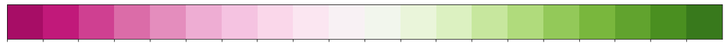

```python
sns.palplot(sns.color_palette("PiYG", 20))
```

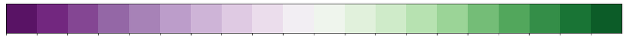

```python
sns.palplot(sns.color_palette("PRGn", 20))
```

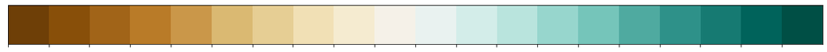

```python
sns.palplot(sns.color_palette("BrBG", 20))
```

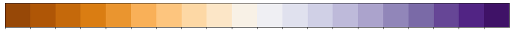

```python
sns.palplot(sns.color_palette("PuOr", 20))
```

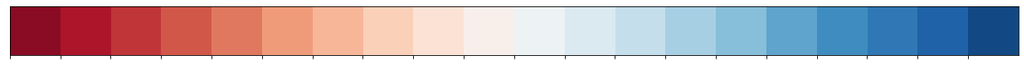

```python
sns.palplot(sns.color_palette("RdBu", 20))
```

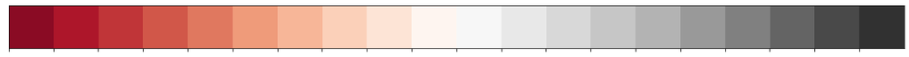

```python
sns.palplot(sns.color_palette("RdGy", 20))
```

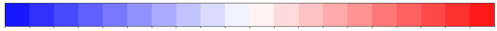

```python
sns.palplot(sns.color_palette("bwr", 20))
```

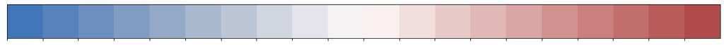

```python
sns.palplot(sns.color_palette("vlag", 20))
```

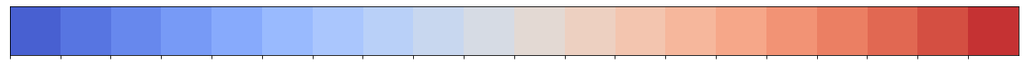

```python
sns.palplot(sns.color_palette("coolwarm", 20))
```

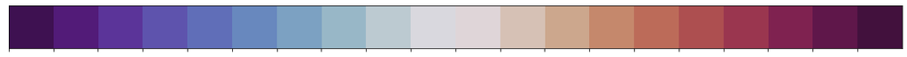

```python
sns.palplot(sns.color_palette("twilight_shifted", 20))
```

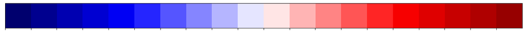

```python
sns.palplot(sns.color_palette("seismic", 20))
```

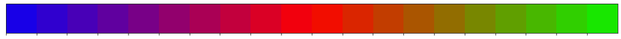

```python
sns.palplot(sns.color_palette("brg", 20))
```

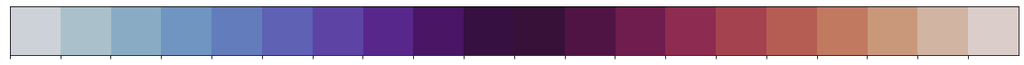

```python
sns.palplot(sns.color_palette("twilight", 20))
```

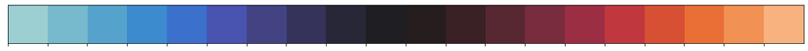

```python
sns.palplot(sns.color_palette("icefire", 20))
```

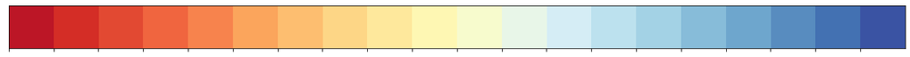

```python
sns.palplot(sns.color_palette("RdYlBu", 20))
```

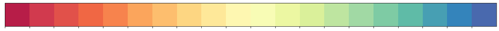

```python
sns.palplot(sns.color_palette("Spectral", 20))
```

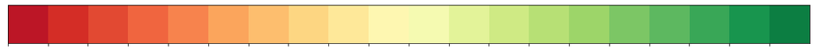

```python
sns.palplot(sns.color_palette("RdYlGn", 20))
```

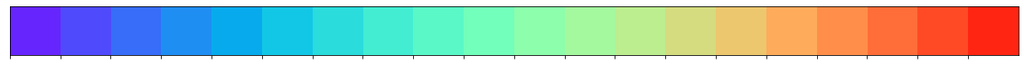

```python
sns.palplot(sns.color_palette("rainbow", 20))
```

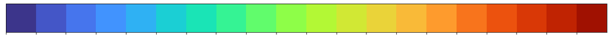

```python
sns.palplot(sns.color_palette("turbo", 20))
```

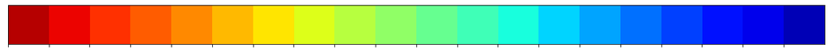

```python
sns.palplot(sns.color_palette("jet_r", 20))
```

### Sequential (последовательные)

Последовательные палитры лучше всего подходят для визуализации плавного изменения числовых значений, чаще всего это двумерные гистограммы, тепловые карты или kde-графики. Здесь важно использовать цветовые палитры из одного цвета, с плавным изменением яркости и насыщенности. Это связано с тем, что если между значениями в данных есть очень большие разрывы, то использование нескольких цветов не позволит это заметить.

Источник: [PyProg Управление цветом](https://pyprog.pro/sns/sns_12_color_setting.html)

В Matplotlib, что бы сменить направление изменения насыщенности и яркости нужно к названию палитры добавить суффикс '_r':

- sns.color_palette('Greens', 10) # прямое направление
- sns.color_palette('Greens_r', 10) # обратное направление

В Seaborn есть еще один суффикс - '_d', который позволяет "затемнить" последовательну палитру:

- sns.color_palette('Greens_d', 10)

Sequential palettes are best suited for visualizing smooth changes in numerical values, most often two-dimensional histograms, heat maps or kde graphs. It is important to use color palettes of the same color, with a smooth change in brightness and saturation. This is due to the fact that if there are very large gaps between the values in the data, then using multiple colors will not allow you to notice it.

In Matplotlib, to change the direction of saturation and brightness changes, you need to add the suffix '_r' to the name of the palette:

- sns.color_palette('Greens', 10) # forward direction
- sns.color_palette('Greens_r', 10) # reverse direction

Seaborn has another suffix - '_d', which allows you to "darken" the palette sequentially:

- sns.color_palette('Greens_d', 10)

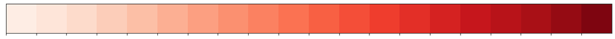

```python
sns.palplot(sns.color_palette("Reds", 20))
```

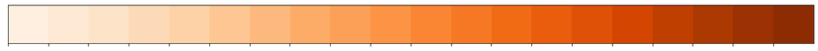

```python
sns.palplot(sns.color_palette("Oranges", 20))
```

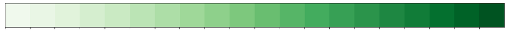

```python
sns.palplot(sns.color_palette("Greens", 20))
```

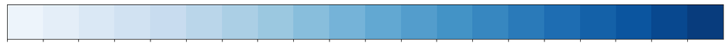

```python
sns.palplot(sns.color_palette("Blues", 20))
```

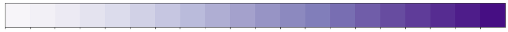

```python
sns.palplot(sns.color_palette("Purples", 20))
```

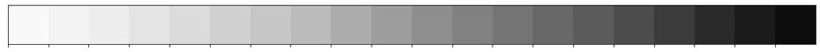

```python
sns.palplot(sns.color_palette("Greys", 20))
```

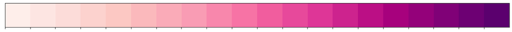

```python
sns.palplot(sns.color_palette("RdPu", 20))
```

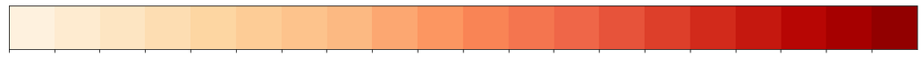

```python
sns.palplot(sns.color_palette("OrRd", 20))
```